# SAiVR_Analysis

**SAiVR Analysis Notebook**

This notebook contains code for analysing and visualizing the results of the SAiVR study project. Currently the focus lies in analysing the results of the three different tasks: Absolute orientation task, Relative orientation task and Pointing task. To work with this notebook you need to have the google spreadsheet of the NBP-VR-Lab and the mat files containing the results of the subjects stored locally.

```python
import os
import numpy as np
import pandas as pd
import seaborn as sns
import matplotlib.pyplot as plt
import scipy
import scipy.io as spio
import pingouin as pg
import itertools
import ptitprince as pt
from statsmodels.stats.anova import AnovaRM
import statsmodels.api as sm
import statsmodels.formula.api as smf
from statsmodels.formula.api import ols
from scipy import stats
sns.set(context = "paper", style="white", palette="Set1", font_scale=2.5, rc={'figure.figsize':(12,9)})
```

Set the correct path information for the google spreadsheet and the mat files to read them in. This has to be adapted to the individual location on your machine.

```python
# define the path leading to the folder with the mat files
taskPath = "C:/Users/mein/Desktop/Cognitive Science/Saivr/Data/TaskResults"
# define the path to the xlsx file containing the spreadsheet of the lab
calenderPath = "C:/Users/mein/Desktop/Cognitive Science/Saivr/Data/Seahaven_alignment_project.xlsx"
# define the path for storing the plots
PLOTS_PATH = "C:/Users/mein/Desktop/Cognitive Science/Saivr/Data/Cohort2/plots/"
```

**Preprocessing**

```python
# import calender file, only load specified columns
df = pd.read_excel(calenderPath, usecols='A,C:G')
df["Training"] = df["Training"].str.lower()
df = df[df.Discarded != 'yes']
# only keep identifier (letter)
df["Repeated"]= df["Repeated"].str[1:]
df.rename(columns={"Subject#": "Subject", "Measurement#": "Measurement"}, inplace=True)
# I included 4j even though it is flagged as discarded (removed), because it was also included before
Ctmpdf = (
    df
    .query('Measurement == 4')
    .query('Training == "belt_c"')
    [['Repeated']]
)
Etmpdf = (
    df
    .query('Measurement == 4')
    .query('Training == "belt_e"')
    [['Repeated']]
)
c_val_ids = Ctmpdf.Repeated.unique()
e_val_ids = Etmpdf.Repeated.unique()
display(c_val_ids)
display(e_val_ids)
c_measure = df[df.Training == "belt_c"][["Subject", "Measurement", "Repeated", "Training"]]
c_measure = c_measure[c_measure['Repeated'].isin(c_val_ids)]
c_val_subs = c_measure["Subject"].unique()
# get the data on all experimental participants
e_measure = df[df.Training == "belt_e"][["Subject", "Measurement", "Repeated", "Training"]]
e_measure = e_measure[e_measure['Repeated'].isin(e_val_ids)]
e_val_subs = e_measure["Subject"].unique()
# combine control and experimental subjects in one data frame
measure_df = pd.concat([c_measure, e_measure])
measure_df["Training"] = measure_df["Training"].str[-1]

print(np.sort(measure_df["Subject"].unique()))
print(len(measure_df["Subject"].unique()))
```

```
array(['i', 'q', 'p', 'a', 'b', 'c', 'k'], dtype=object)
```

```
array(['g', 'b', 'j', 'f', 'k', 'i', 'h', 'a', 'd', 'sj', 'sa', 'sl',
       'so', 'si', 'sp', 'sd', 'se', 'sc', 'sb', 'sm', 'sh', 'sn', 'sq',
       'sg'], dtype=object)
```

```
[1033 1208 1297 1316 1357 1449 1493 1535 1570 1753 1815 1844 1879 1906
 1921 1975 2015 2025 2121 2190 2288 2354 2366 2388 2497 2639 2647 2723
 2784 2855 2868 2869 2906 2989 3057 3142 3160 3288 3323 3597 3617 3750
 3868 4059 4134 4156 4160 4225 4270 4346 4471 4473 4493 4558 4570 4855
 4870 4935 4958 4991 5044 5149 5338 5348 5354 5356 5422 5532 5549 5617
 5631 5667 5701 5706 5732 5831 6061 6107 6224 6292 6378 6465 6520 6695
 6737 6832 6850 7023 7248 7450 7486 7568 7762 7807 7877 7972 7986 8039
 8089 8114 8207 8215 8253 8259 8663 8669 8670 8674 8740 8869 8902 8933
 8943 9008 9288 9332 9474 9580 9657 9662 9751 9842 9857 9942]
124
```

```python
def mat_to_py(AlignmentPath,number):
    '''
    converts mat struct with task results into (numpy) array

    also adds extra column with information whether trial was correct or wrong

    conditions = ["Absolute - 3s ","Absolute - inf","Relative - 3s ","Relative - inf","Pointing 3s   ","Pointing - inf"]
    '''
    path = AlignmentPath+"/AlignmentVR_SubjNo_"+number+".mat"
    mat_contents = spio.loadmat(path)
    type_array = []
    for i,cond_1 in enumerate(["Absolute", "Relative","Pointing"]):
        for j,cond_2 in enumerate(["Trial_3s", "Trial_Inf"]):
            trials_array = []
            for line in range(len(mat_contents['Output'][0][0][cond_1][cond_2][0][0])):
                value_array = []
                for column in range(len(mat_contents['Output'][0][0][cond_1][cond_2][0][0][line][0])):
                    value = mat_contents['Output'][0][0][cond_1][cond_2][0][0][line][0][column][0][0]
                    value_array.append(value)
                # check if trial is correct(true or false
                value_array.append(value_array[-1] == value_array[-3])
                trials_array.append(value_array)

            type_array.append(trials_array)

    return np.array(type_array)
```

Use mat_to_py function and measures_df data frame to load the performance of all subjects on all tasks into the AllResults data frame.

```python
conditions = ["Absolute - 3s ","Absolute - inf","Relative - 3s ","Relative - inf","Pointing 3s   ","Pointing - inf"]
# get all vp_nums from measure_df data frame
vp_nums = measure_df["Subject"].astype(str).tolist()
AllResults = np.zeros((6,len(vp_nums),36))#AllResults[condition][subjectNum][Trial]
for i,e in enumerate(vp_nums):
    try:
        m = mat_to_py(taskPath,e)
        for c in range(6):
            condperf = []
            for t in range(36):
                condperf.append(int(m[c][t][-1]))
            AllResults[c][i] = condperf
    except:
        print(str(e)+" Not in folder")
```

```python
# construct a performance data frame containing the perfromance (percentage of correct answers) of
# each subject on each task and join this with vpN to get vp_numbers as index
performances = pd.DataFrame()
vpN = pd.DataFrame(vp_nums,columns=['vp_number']).astype(int)
for cond in range(6):
    performances[cond] = np.mean(AllResults[cond],axis=1)
performances.columns = conditions
performances = vpN.join(performances).set_index('vp_number')
#performances
```

```python
# check some overall stats on the performance df
performances.describe()
```

|  | Absolute - 3s | Absolute - inf | Relative - 3s | Relative - inf | Pointing 3s | Pointing - inf |
| --- | --- | --- | --- | --- | --- | --- |
| count | 124.000000 | 124.000000 | 124.000000 | 124.000000 | 124.000000 | 124.000000 |
| mean | 0.505152 | 0.525986 | 0.494400 | 0.517697 | 0.495072 | 0.528674 |
| std | 0.083774 | 0.105060 | 0.089957 | 0.087722 | 0.083224 | 0.083816 |
| min | 0.305556 | 0.250000 | 0.250000 | 0.305556 | 0.277778 | 0.305556 |
| 25% | 0.444444 | 0.444444 | 0.444444 | 0.472222 | 0.444444 | 0.472222 |
| 50% | 0.500000 | 0.527778 | 0.500000 | 0.527778 | 0.500000 | 0.527778 |
| 75% | 0.555556 | 0.583333 | 0.555556 | 0.583333 | 0.555556 | 0.583333 |
| max | 0.722222 | 0.777778 | 0.750000 | 0.777778 | 0.666667 | 0.750000 |

Use performance df and measure_df to create a new data frame containing all the information relevant for further analysis. The final data frame to work with is AllPerformances.

```python
# merge performances and measure_df on vp_numbers
df_all = performances.merge(measure_df, left_on="vp_number", right_on="Subject").set_index("Subject")
#df_all.head()
```

```python
# construct AllPerformances frame
TaskList = ['Absolute','Absolute','Relative','Relative','Pointing','Pointing']
CondList = ['3s','inf','3s','inf','3s','inf']
AllPerformances = pd.DataFrame(columns=['Subject','Task','Condition','Performance', 'Measurement', 'Training'])
for sj in list(df_all.index):
    for i,c in enumerate(conditions):
        AllPerformances = AllPerformances.append({'Subject':df_all.loc[sj]["Repeated"],'Task':TaskList[i],'Condition':CondList[i],'Performance':df_all.loc[sj][c],'Measurement':df_all.loc[sj]["Measurement"],'Training':df_all.loc[sj]['Training']}, ignore_index=True)
```

```python
# Add "TC" column as combination of Task and Condition for later plotting
AllPerformances["TC"] = AllPerformances.Task + " - " + AllPerformances.Condition
# store data of experimental and control group in seperate frames to make plotting easier
AllPerformances_e = AllPerformances[AllPerformances["Training"] == 'e']
AllPerformances_c = AllPerformances[AllPerformances["Training"] == 'c']
AllPerformances.head()
```

|  | Subject | Task | Condition | Performance | Measurement | Training | TC |
| --- | --- | --- | --- | --- | --- | --- | --- |
| 0 | b | Absolute | 3s | 0.472222 | 3 | c | Absolute - 3s |
| 1 | b | Absolute | inf | 0.472222 | 3 | c | Absolute - inf |
| 2 | b | Relative | 3s | 0.527778 | 3 | c | Relative - 3s |
| 3 | b | Relative | inf | 0.555556 | 3 | c | Relative - inf |
| 4 | b | Pointing | 3s | 0.611111 | 3 | c | Pointing - 3s |

AllPerformances contains 7 columns. Subject column identifies each participant with a unique letter. These letters are only unique for when control and experimental group are considered independently. The combination of Training and Subject columns is a unique identifier for each individual subject however. Task contains the name of the task. Condition stores information on the time condition. Performance stores the actual performance for the task and time condition. The measurement column indicates which measurement of the given subject we are considering (1-4). Training stoes information on whether the subject was in the experimental or the control group ('e' or 'c') and TC contains the combination of task and condition.

**Visualizing the data**

First we have a look at boxplots displaying the performance results for the three different tasks and the two different time conditions. This is done seperately for experimental and control subjects.

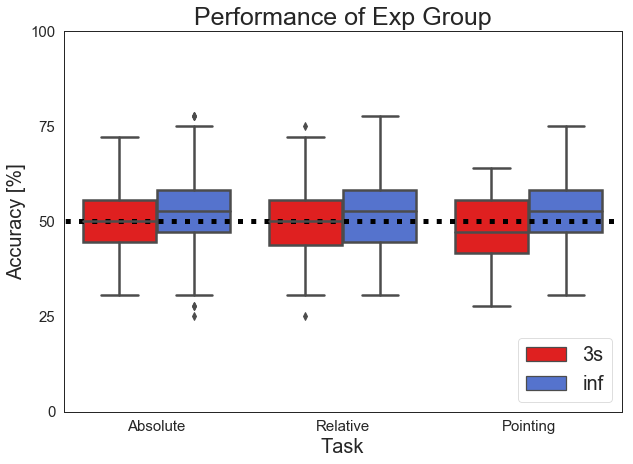

```python
#group tasks
#color by time condition
fig,ax = plt.subplots(figsize=(10,7))
# add the chance level line
plt.plot([-5,10],[0.5,0.5],':',color='black', linewidth=5)
# create the boxplots
sns.boxplot(data=AllPerformances_e,hue='Condition',x='Task',y='Performance', palette=["red", "royalblue"],linewidth=2.5)
# set the aestethics
ax.set_xticklabels(['Absolute','Relative','Pointing'],fontsize=15)
ax.set_ylim((0,1))
plt.legend(fontsize=20,loc=4)
plt.title('Performance of Exp Group',fontsize=25)
plt.ylabel('Accuracy [%]',fontsize=20)
plt.yticks(np.linspace(0,1,5),np.linspace(0,100,5,dtype=int),fontsize=15)
plt.xlabel("Task",fontsize=20);
#plt.show()
#plt.savefig('Results/TaskPerformancesGrouped.png', bbox_inches='tight')
plt.savefig(PLOTS_PATH+'TaskPerformancesExp.png', quality=90)
```

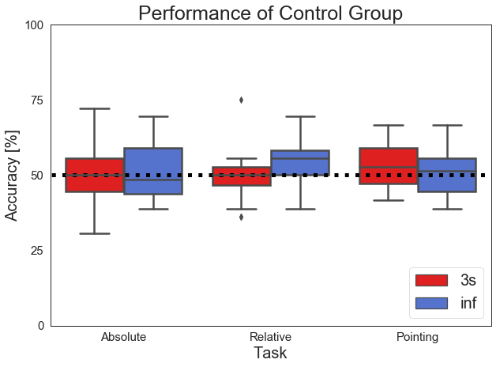

```python
#group tasks
#color by time condition
fig,ax = plt.subplots(figsize=(10,7))
plt.plot([-5,10],[0.5,0.5],':',color='black', linewidth=5)
sns.boxplot(data=AllPerformances_c,hue='Condition',x='Task',y='Performance', palette=["red", "royalblue"],linewidth=2.5)
ax.set_xticklabels(['Absolute','Relative','Pointing'],fontsize=15)
ax.set_ylim((0,1))
plt.legend(fontsize=20,loc=4)
plt.title('Performance of Control Group',fontsize=25)
plt.ylabel('Accuracy [%]',fontsize=20)
plt.yticks(np.linspace(0,1,5),np.linspace(0,100,5,dtype=int),fontsize=15)
plt.xlabel("Task",fontsize=20);
#plt.show()
#plt.savefig('Results/TaskPerformancesGrouped.png', bbox_inches='tight')
plt.savefig(PLOTS_PATH+'TaskPerformancesControl.png', quality=90)
```

Now we have a look at the performance for the different measurements. Again this is done seperately for each combination of task and time condition and for experimental and control subjects.

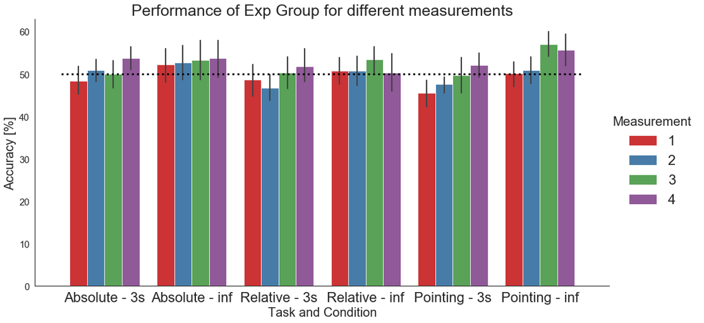

```python
sns.catplot(x='TC', y='Performance', hue='Measurement', data=AllPerformances_e, kind='bar', height=7, aspect=2)
#plt.plot([-0.45,5.4],[0.5,0.5],':',color='black', linewidth=3)
#plt.legend(fontsize=20,loc=4)
plt.title('Performance of Exp Group for different measurements',fontsize=25)
plt.ylabel('Accuracy [%]',fontsize=20)
plt.yticks(np.linspace(0,0.7,8),np.linspace(0,70,8,dtype=int),fontsize=15)
plt.xlabel("Task and Condition",fontsize=20)
plt.plot([-0.5,5.5],[0.5,0.5],':',color='black', linewidth=3);
plt.savefig(PLOTS_PATH+'TaskPerformancesExpMeasurement.png', quality=90)
```

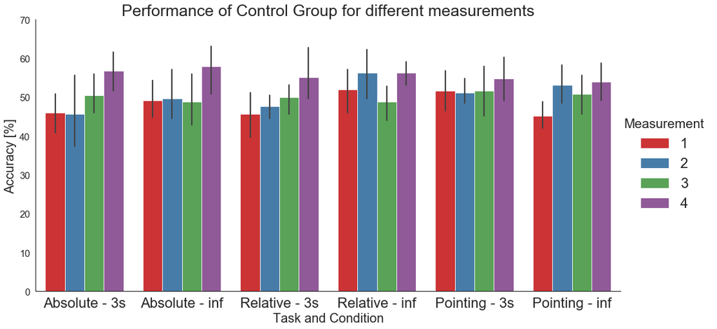

```python
sns.catplot(x='TC', y='Performance', hue='Measurement', data=AllPerformances_c, kind='bar', height=7, aspect=2)
#plt.plot([-0.45,5.4],[0.5,0.5],':',color='black', linewidth=3)
#plt.legend(fontsize=20,loc=4)
plt.title('Performance of Control Group for different measurements',fontsize=25)
plt.ylabel('Accuracy [%]',fontsize=20)
plt.yticks(np.linspace(0,0.7,8),np.linspace(0,70,8,dtype=int),fontsize=15)
plt.xlabel("Task and Condition",fontsize=20);
plt.savefig(PLOTS_PATH+'TaskPerformancesControlMeasurement.png', quality=90)
```

Next we have a look at a raincloud plot. Here we mix experimental and control subjects to visualize all the available data once.

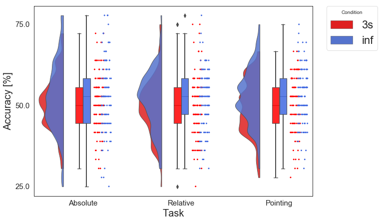

```python
#Plotting adapted from https://peerj.com/preprints/27137v1/
ax = pt.RainCloud(data=AllPerformances,hue='Condition',x='Task',y='Performance', palette=["red", "royalblue"],bw = 0.2,
                 width_viol = .5, figsize = (10,7),pointplot = False, alpha = .85, dodge = True, move = 0.2)

ax.set_xticklabels(['Absolute','Relative','Pointing'],fontsize=15)
#ax.legend(['3s','inf'],fontsize=20,loc=1)

#plt.title('Performance of Subjects in the Tasks',fontsize=25)
plt.ylabel('Accuracy [%]',fontsize=20)
plt.xlabel("Task",fontsize=20)
plt.yticks(np.linspace(0.25,0.75,3),np.linspace(25,75,3),fontsize=15);
#plt.show()
#plt.savefig('Results/TaskPerformancesRainCloud.png', bbox_inches='tight')
plt.savefig(PLOTS_PATH+'PerformanceRainCloud.png', quality=90)
```

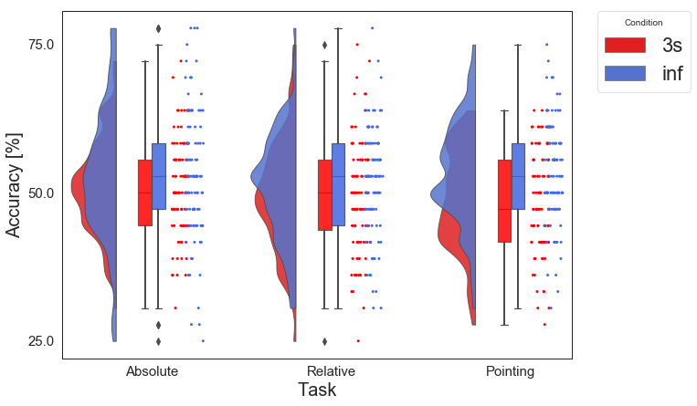

```python
#Plotting adapted from https://peerj.com/preprints/27137v1/
ax = pt.RainCloud(data=AllPerformances_e,hue='Condition',x='Task',y='Performance', palette=["red", "royalblue"],bw = 0.2,
                 width_viol = .5, figsize = (10,7),pointplot = False, alpha = .85, dodge = True, move = 0.2)

ax.set_xticklabels(['Absolute','Relative','Pointing'],fontsize=15)
#ax.legend(['3s','inf'],fontsize=20,loc=1)

#plt.title('Performance of exp. subjects in the Tasks',fontsize=25)
plt.ylabel('Accuracy [%]',fontsize=20)
plt.xlabel("Task",fontsize=20)
plt.yticks(np.linspace(0.25,0.75,3),np.linspace(25,75,3),fontsize=15);
#plt.show()
#plt.savefig('Results/TaskPerformancesRainCloud.png', bbox_inches='tight')
plt.savefig(PLOTS_PATH+'PerformanceRainCloudExp.png', quality=90)
```

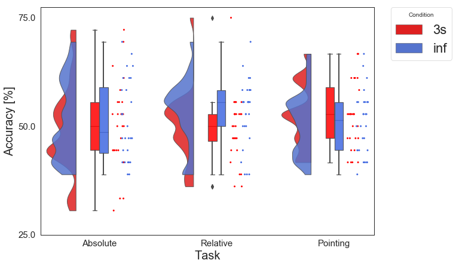

```python
#Plotting adapted from https://peerj.com/preprints/27137v1/
ax = pt.RainCloud(data=AllPerformances_c,hue='Condition',x='Task',y='Performance', palette=["red", "royalblue"],bw = 0.2,
                 width_viol = .5, figsize = (10,7),pointplot = False, alpha = .85, dodge = True, move = 0.2)

ax.set_xticklabels(['Absolute','Relative','Pointing'],fontsize=15)
#ax.legend(['3s','inf'],fontsize=20,loc=1)

#plt.title('Performance of cont. subjects in the Tasks',fontsize=25)
plt.ylabel('Accuracy [%]',fontsize=20)
plt.xlabel("Task",fontsize=20)
plt.yticks(np.linspace(0.25,0.75,3),np.linspace(25,75,3),fontsize=15);
#plt.show()
#plt.savefig('Results/TaskPerformancesRainCloud.png', bbox_inches='tight')
plt.savefig(PLOTS_PATH+'PerformanceRainCloudControl.png', quality=90)
```

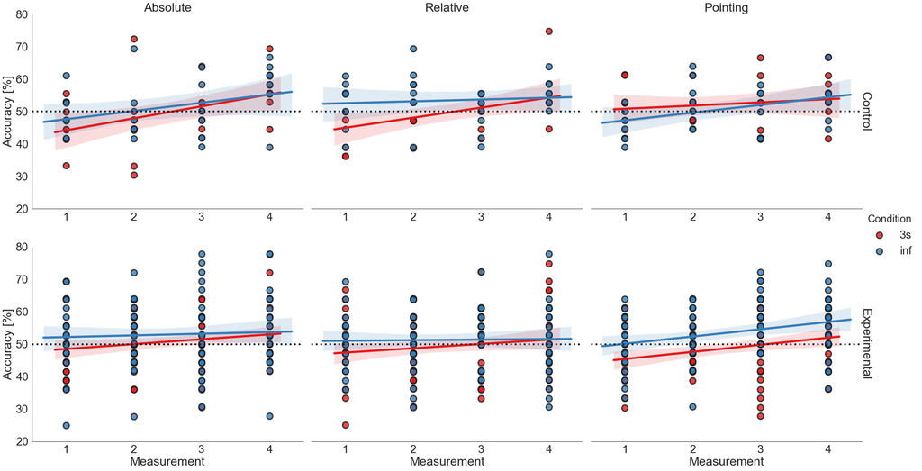

```python
sns.set(context = "paper", style="white", palette="Set1", font_scale=3, rc={'figure.figsize':(30,10)})
tmp = AllPerformances
tmp = tmp.astype({'Measurement': 'float64'})
tmp.Performance = tmp.Performance*100
tmp = (tmp
        .rename(columns={'Performance': 'Accuracy [%]'})
)
g = sns.lmplot(data=tmp, x='Measurement', y='Accuracy [%]',hue='Condition',
               col='Task', row='Training',
               x_ci='ci', ci=95, n_boot=1000,
#                robust=True,
               height=8, aspect=1.2,
               sharex=False,
               y_jitter=0.2,
               scatter_kws={"s": 200, 'edgecolors':'k', 'linewidths': 3},
               line_kws={'linewidth': 5})
i=0
for ax,title in zip(g.axes.flat,['Absolute','Relative','Pointing','Exp-Absolute','Exp-Relative','Exp-Pointing']):
    i = i+1
    ax.axhline(50, ls=':', color='k', lw=4)
    if i not in [1,4,7]:
        ax.spines['left'].set_visible(False)
    ax.set(ylim=(20,80),xlim=(0.5,4.5),  xticks=[1, 2, 3,4], xlabel = 'Measurement')
    if i in [1,2,3]:
        ax.set(xlabel='')
        ax.set_title(title)
    else:
        ax.set_title('')
    if i==3:
        ax.yaxis.set_label_position('right')
        ax.set_ylabel(ylabel = 'Control', labelpad=20)
        ax.yaxis.label.set_rotation(-90)
    if i==6:
        ax.yaxis.set_label_position('right')
        ax.set_ylabel(ylabel = 'Experimental', labelpad=20)
        ax.yaxis.label.set_rotation(-90)
g = g.fig.subplots_adjust(wspace=.03)
# plt.show()
#plt.savefig(PLOTS_PATH+'Group_Measurement_Task_Time.png', quality=90)
```

**Statistics - Dive into the data**

After having had a look at different visualizations of the data, we are going to do some more rigorous analysis. We start of investigating the performance in relation to different dependent variables, such as Measurement or Condition and Task. In case any of those variables reveals itself to have a significant influence on the performance, we perform paired t-tests to pinpoint the relevant value for which the mean performance differs from the rest. Again we treat control and experimental subjects seperately.

```python
AllPerformances.groupby(['Training', 'Condition'])['Performance'].agg(['mean', 'std']).round(3)
```

| Training | Condition | mean | std |
| --- | --- | --- | --- |
| c | 3s | 0.505 | 0.085 |
|  | inf | 0.519 | 0.080 |
| e | 3s | 0.496 | 0.086 |
|  | inf | 0.526 | 0.096 |

```python
AllPerformances.groupby(['Training', 'Task'])['Performance'].agg(['mean', 'std']).round(3)
```

| Training | Task | mean | std |
| --- | --- | --- | --- |
| c | Absolute | 0.505 | 0.095 |
|  | Pointing | 0.515 | 0.073 |
|  | Relative | 0.515 | 0.079 |
| e | Absolute | 0.519 | 0.096 |
|  | Pointing | 0.511 | 0.088 |
|  | Relative | 0.503 | 0.092 |

```python
AllPerformances.groupby(['Training', 'Measurement'])['Performance'].agg(['mean', 'std']).round(3)
```

| Training | Measurement | mean | std |
| --- | --- | --- | --- |
| c | 1 | 0.483 | 0.075 |
|  | 2 | 0.506 | 0.090 |
|  | 3 | 0.501 | 0.072 |
|  | 4 | 0.558 | 0.075 |
| e | 1 | 0.493 | 0.089 |
|  | 2 | 0.499 | 0.082 |
|  | 3 | 0.523 | 0.098 |
|  | 4 | 0.529 | 0.095 |

```python
m = AllPerformances.groupby('Measurement')['Performance'].agg(['mean', 'std']).round(3)
c = AllPerformances.groupby('Condition')['Performance'].agg(['mean', 'std']).round(3)
t = AllPerformances.groupby('Task')['Performance'].agg(['mean', 'std']).round(3)
display(m,c,t)
```

| Measurement | mean | std |
| --- | --- | --- |
| 1 | 0.490 | 0.086 |
| 2 | 0.501 | 0.083 |
| 3 | 0.518 | 0.093 |
| 4 | 0.536 | 0.091 |

| Condition | mean | std |
| --- | --- | --- |
| 3s | 0.498 | 0.086 |
| inf | 0.524 | 0.093 |

| Task | mean | std |
| --- | --- | --- |
| Absolute | 0.516 | 0.095 |
| Pointing | 0.512 | 0.085 |
| Relative | 0.506 | 0.089 |

We first look at the experimental group.

```python
# Anova experimental group
anovarm = AnovaRM(data=AllPerformances_e,depvar='Performance',subject='Subject',within=['Task','Condition','Measurement'])
fit = anovarm.fit()
fit.summary()
```

|  | F Value | Num DF | Den DF | Pr > F |
| --- | --- | --- | --- | --- |
| Task | 1.6455 | 2.0000 | 46.0000 | 0.2041 |
| Condition | 14.4701 | 1.0000 | 23.0000 | 0.0009 |
| Measurement | 5.0284 | 3.0000 | 69.0000 | 0.0033 |
| Task:Condition | 0.8569 | 2.0000 | 46.0000 | 0.4311 |
| Task:Measurement | 1.3428 | 6.0000 | 138.0000 | 0.2423 |
| Condition:Measurement | 1.8012 | 3.0000 | 69.0000 | 0.1551 |
| Task:Condition:Measurement | 0.3738 | 6.0000 | 138.0000 | 0.8946 |

```python
new_anova_rm = pg.rm_anova(dv="Performance", subject="Subject", within=['Task','Measurement'], data=AllPerformances_e)
pg.print_table(new_anova_rm)
```

```
=============
ANOVA SUMMARY
=============

Source                 SS    ddof1    ddof2     MS      F    p-unc    p-GG-corr    np2    eps
------------------  -----  -------  -------  -----  -----  -------  -----------  -----  -----
Task                0.011        2       46  0.005  1.646    0.204        0.204  0.067  0.991
Measurement         0.068        3       69  0.023  5.028    0.003        0.010  0.179  0.696
Task * Measurement  0.025        6      138  0.004  1.343    0.242        0.263  0.055  0.611
```

```python
data = AllPerformances_e[AllPerformances_e['Condition']=='inf']
new_anova_rm = pg.rm_anova(dv="Performance", subject="Subject", within=['Task','Measurement'], data=data)
pg.print_table(new_anova_rm)
```

```
=============
ANOVA SUMMARY
=============

Source                 SS    ddof1    ddof2     MS      F    p-unc    p-GG-corr    np2    eps
------------------  -----  -------  -------  -----  -----  -------  -----------  -----  -----
Task                0.025        2       46  0.012  1.221    0.304        0.303  0.050  0.934
Measurement         0.059        3       69  0.020  2.600    0.059        0.065  0.102  0.906
Task * Measurement  0.043        6      138  0.007  1.005    0.425        0.408  0.042  0.646
```

```python
new_anova_rm = pg.rm_anova(dv="Performance", subject="Subject", within=['Condition','Measurement'], data=AllPerformances_e)
pg.print_table(new_anova_rm)
```

```
=============
ANOVA SUMMARY
=============

Source                      SS    ddof1    ddof2     MS       F    p-unc    p-GG-corr    np2    eps
-----------------------  -----  -------  -------  -----  ------  -------  -----------  -----  -----
Condition                0.042        1       23  0.042  14.470    0.001        0.001  0.386  1.000
Measurement              0.045        3       69  0.015   5.028    0.003        0.010  0.179  0.696
Condition * Measurement  0.010        3       69  0.003   1.801    0.155        0.162  0.073  0.892
```

```python
new_anova_rm = pg.rm_anova(dv="Performance", subject="Subject", within=['Task','Condition'], data=AllPerformances_e)
pg.print_table(new_anova_rm)
```

```
=============
ANOVA SUMMARY
=============

Source               SS    ddof1    ddof2     MS       F    p-unc    p-GG-corr    np2    eps
----------------  -----  -------  -------  -----  ------  -------  -----------  -----  -----
Task              0.005        2       46  0.003   1.646    0.204        0.204  0.067  0.991
Condition         0.032        1       23  0.032  14.470    0.001        0.001  0.386  1.000
Task * Condition  0.006        2       46  0.003   0.857    0.431        0.426  0.036  0.944
```

```python
M_4_e = AllPerformances_e[AllPerformances_e["Measurement"]==3]
new_anova_rm = pg.rm_anova(dv="Performance", subject="Subject", within=['Task','Condition'], data=M_4_e)
pg.print_table(new_anova_rm)
```

```
=============
ANOVA SUMMARY
=============

Source               SS    ddof1    ddof2     MS       F    p-unc    p-GG-corr    np2    eps
----------------  -----  -------  -------  -----  ------  -------  -----------  -----  -----
Task              0.008        2       46  0.004   0.601    0.552        0.549  0.025  0.975
Condition         0.076        1       23  0.076  11.978    0.002        0.002  0.342  1.000
Task * Condition  0.014        2       46  0.007   0.709    0.498        0.486  0.030  0.917
```

```python
# Anova exp, no k, j  -> include only participants that had all measurements completed at the time of writing (11.07.19)
# keep this and the analysis done on test frame for now and out of curiosity, but ultimately we care about AllPerformances_e
test = AllPerformances_e[AllPerformances_e['Subject']!='k']
test = test[test['Subject']!='j']
anovarm = AnovaRM(data=test,depvar='Performance',subject='Subject',within=['Task','Condition','Measurement'])
fit = anovarm.fit()
fit.summary()
```

|  | F Value | Num DF | Den DF | Pr > F |
| --- | --- | --- | --- | --- |
| Task | 1.9451 | 2.0000 | 42.0000 | 0.1556 |
| Condition | 10.9421 | 1.0000 | 21.0000 | 0.0033 |
| Measurement | 4.9812 | 3.0000 | 63.0000 | 0.0036 |
| Task:Condition | 0.8740 | 2.0000 | 42.0000 | 0.4247 |
| Task:Measurement | 1.6593 | 6.0000 | 126.0000 | 0.1364 |
| Condition:Measurement | 2.1183 | 3.0000 | 63.0000 | 0.1068 |
| Task:Condition:Measurement | 0.3882 | 6.0000 | 126.0000 | 0.8855 |

There are a lot of significant variables here. We will proceed with paired t-tests. Do not forget to use the Bonferroni correction: $\alpha_{b}=\alpha / q$, with q being the number of comparisions.

```python
0.05/3
```

```
0.016666666666666666
```

```python
# Extract performances for each task
Abs = AllPerformances_e[AllPerformances_e['Task']=='Absolute']['Performance']
Rel = AllPerformances_e[AllPerformances_e['Task']=='Relative']['Performance']
Ptg = AllPerformances_e[AllPerformances_e['Task']=='Pointing']['Performance']
# print the reults of the paired t-tests for all possible combinations
print("Abs - Rel: "+str(stats.ttest_rel(Abs, Rel)))
print("Abs - Ptg: "+str(stats.ttest_rel(Abs, Ptg)))
print("Rel - Ptg: "+str(stats.ttest_rel(Rel, Ptg)))
```

```
Abs - Rel: Ttest_relResult(statistic=1.7095317687209508, pvalue=0.08897656957424911)
Abs - Ptg: Ttest_relResult(statistic=0.8783053883966105, pvalue=0.3808815449250461)
Rel - Ptg: Ttest_relResult(statistic=-0.8552456984180664, pvalue=0.393486683618008)
```

```python
# Extract performances for each task
Abs = test[test['Task']=='Absolute']['Performance']
Rel = test[test['Task']=='Relative']['Performance']
Ptg = test[test['Task']=='Pointing']['Performance']
# print the reults of the paired t-tests for all possible combinations
print("Abs - Rel: "+str(stats.ttest_rel(Abs, Rel)))
print("Abs - Ptg: "+str(stats.ttest_rel(Abs, Ptg)))
print("Rel - Ptg: "+str(stats.ttest_rel(Rel, Ptg)))
```

```
Abs - Rel: Ttest_relResult(statistic=1.8956435736592503, pvalue=0.059655496641296275)
Abs - Ptg: Ttest_relResult(statistic=0.7687878085038444, pvalue=0.44305557292213715)
Rel - Ptg: Ttest_relResult(statistic=-1.1463180076977388, pvalue=0.2532285905637962)
```

```python
# Extract performances for each condition
Short = AllPerformances_e[AllPerformances_e['Condition']=='3s']['Performance']
Inf = AllPerformances_e[AllPerformances_e['Condition']=='inf']['Performance']
# print the reults of the paired t-tests for all possible combinations
print("Short - Inf: "+str(stats.ttest_rel(Short, Inf)))
```

```
Short - Inf: Ttest_relResult(statistic=-4.090314297507658, pvalue=5.600983489603978e-05)
```

```python
0.05/6
```

```
0.008333333333333333
```

```python
# Extract performances for each measurement
Measurement_1 = test[test['Measurement']==1]['Performance']
Measurement_2 = test[test['Measurement']==2]['Performance']
Measurement_3 = test[test['Measurement']==3]['Performance']
Measurement_4 = test[test['Measurement']==4]['Performance']
# print the reults of the paired t-tests for all possible combinations
print("M_1 - M_2: "+str(stats.ttest_rel(Measurement_1, Measurement_2)))
print("M_1 - M_3: "+str(stats.ttest_rel(Measurement_1, Measurement_3)))
print("M_1 - M_4: "+str(stats.ttest_rel(Measurement_1, Measurement_4)))
print("M_2 - M_3: "+str(stats.ttest_rel(Measurement_2, Measurement_3)))
print("M_2 - M_4: "+str(stats.ttest_rel(Measurement_2, Measurement_4)))
print("M_3 - M_4: "+str(stats.ttest_rel(Measurement_3, Measurement_4)))
```

```
M_1 - M_2: Ttest_relResult(statistic=-0.7745543447878246, pvalue=0.43999879025836597)
M_1 - M_3: Ttest_relResult(statistic=-3.0588539850451357, pvalue=0.0026948990539119927)
M_1 - M_4: Ttest_relResult(statistic=-3.2631146420651698, pvalue=0.0014055198349176901)
M_2 - M_3: Ttest_relResult(statistic=-2.589270182739161, pvalue=0.010705277743871252)
M_2 - M_4: Ttest_relResult(statistic=-2.922678490090773, pvalue=0.004089284645204789)
M_3 - M_4: Ttest_relResult(statistic=-0.4594780348005127, pvalue=0.6466525063913842)
```

```python
# Extract performances for each measurement
Measurement_1 = AllPerformances_e[AllPerformances_e['Measurement']==1]['Performance']
Measurement_2 = AllPerformances_e[AllPerformances_e['Measurement']==2]['Performance']
Measurement_3 = AllPerformances_e[AllPerformances_e['Measurement']==3]['Performance']
Measurement_4 = AllPerformances_e[AllPerformances_e['Measurement']==4]['Performance']
# print the reults of the paired t-tests for all possible combinations
print("M_1 - M_2: "+str(stats.ttest_rel(Measurement_1, Measurement_2)))
print("M_1 - M_3: "+str(stats.ttest_rel(Measurement_1, Measurement_3)))
print("M_1 - M_4: "+str(stats.ttest_rel(Measurement_1, Measurement_4)))
print("M_2 - M_3: "+str(stats.ttest_rel(Measurement_2, Measurement_3)))
print("M_2 - M_4: "+str(stats.ttest_rel(Measurement_2, Measurement_4)))
print("M_3 - M_4: "+str(stats.ttest_rel(Measurement_3, Measurement_4)))
```

```
M_1 - M_2: Ttest_relResult(statistic=-0.6779097612845968, pvalue=0.4989243314727664)
M_1 - M_3: Ttest_relResult(statistic=-2.866097393390899, pvalue=0.004783585912074432)
M_1 - M_4: Ttest_relResult(statistic=-3.199550921270985, pvalue=0.001695563597167798)
M_2 - M_3: Ttest_relResult(statistic=-2.291994720722717, pvalue=0.023365898288543546)
M_2 - M_4: Ttest_relResult(statistic=-2.875000874227632, pvalue=0.004658002039559856)
M_3 - M_4: Ttest_relResult(statistic=-0.5341880133521898, pvalue=0.5940409482136703)
```

```python
# Extract performances for each measurement and short time condition
M_1 = test[test['Measurement']==1]
M_2 = test[test['Measurement']==2]
M_3 = test[test['Measurement']==3]
M_4 = test[test['Measurement']==4]
# get short time condition
MC_1s = M_1[M_1['Condition']=='3s']['Performance']
MC_2s = M_2[M_2['Condition']=='3s']['Performance']
MC_3s = M_3[M_3['Condition']=='3s']['Performance']
MC_4s = M_4[M_4['Condition']=='3s']['Performance']
# get long time condition
MC_1l = M_1[M_1['Condition']=='inf']['Performance']
MC_2l = M_2[M_2['Condition']=='inf']['Performance']
MC_3l = M_3[M_3['Condition']=='inf']['Performance']
MC_4l = M_4[M_4['Condition']=='inf']['Performance']
# print the reults of the paired t-tests for all possible combinations
print("MC_1s - MC_2s: "+str(stats.ttest_rel(MC_1s, MC_2s)))
print("MC_1s - MC_3s: "+str(stats.ttest_rel(MC_1s, MC_3s)))
print("MC_1s - MC_4s: "+str(stats.ttest_rel(MC_1s, MC_4s)))
print("MC_2s - MC_3s: "+str(stats.ttest_rel(MC_2s, MC_3s)))
print("MC_2s - MC_4s: "+str(stats.ttest_rel(MC_2s, MC_4s)))
print("MC_3s - MC_4s: "+str(stats.ttest_rel(MC_3s, MC_4s)))

print("MC_1l - MC_2l: "+str(stats.ttest_rel(MC_1l, MC_2l)))
print("MC_1l - MC_3l: "+str(stats.ttest_rel(MC_1l, MC_3l)))
print("MC_1l - MC_4l: "+str(stats.ttest_rel(MC_1l, MC_4l)))
print("MC_2l - MC_3l: "+str(stats.ttest_rel(MC_2l, MC_3l)))
print("MC_2l - MC_4l: "+str(stats.ttest_rel(MC_2l, MC_4l)))
print("MC_3l - MC_4l: "+str(stats.ttest_rel(MC_3l, MC_4l)))
```

```
MC_1s - MC_2s: Ttest_relResult(statistic=-0.3126409456585237, pvalue=0.7555543234607112)
MC_1s - MC_3s: Ttest_relResult(statistic=-1.4760198619655582, pvalue=0.14476678490441325)
MC_1s - MC_4s: Ttest_relResult(statistic=-3.3036280578309474, pvalue=0.0015547608228872268)
MC_2s - MC_3s: Ttest_relResult(statistic=-1.2746606022542672, pvalue=0.20696731175095923)
MC_2s - MC_4s: Ttest_relResult(statistic=-3.389543618719444, pvalue=0.0011941186958022178)
MC_3s - MC_4s: Ttest_relResult(statistic=-1.795920864037116, pvalue=0.07715476233172022)
MC_1l - MC_2l: Ttest_relResult(statistic=-0.7986532038128409, pvalue=0.42740008375890304)
MC_1l - MC_3l: Ttest_relResult(statistic=-2.769991549236811, pvalue=0.007299765341571999)
MC_1l - MC_4l: Ttest_relResult(statistic=-1.5848250730357498, pvalue=0.11785966808089313)
MC_2l - MC_3l: Ttest_relResult(statistic=-2.314405349588819, pvalue=0.023815636277594115)
MC_2l - MC_4l: Ttest_relResult(statistic=-1.124087050007254, pvalue=0.2651103533017063)
MC_3l - MC_4l: Ttest_relResult(statistic=0.987578196672336, pvalue=0.3270213135759392)
```

**Non-parametric tests**

```python
from scipy.stats import friedmanchisquare
# The test assumes two or more paired data samples with 10 or more samples per group
data1 = AllPerformances_e[AllPerformances_e['Task']=='Absolute']['Performance']
data2 = AllPerformances_e[AllPerformances_e['Task']=='Relative']['Performance']
data3 = AllPerformances_e[AllPerformances_e['Task']=='Pointing']['Performance']
# compare samples
stat, p = friedmanchisquare(data1, data2, data3)
print('Statistics=%.3f, p=%.3f' % (stat, p))
```

```
Statistics=5.235, p=0.073
```

Now we have a look at the controls. There are only 7 fully measured control participants.

```python
# Anova control
anovarm = AnovaRM(data=AllPerformances_c,depvar='Performance',subject='Subject',within=['Task','Condition','Measurement'])
fit = anovarm.fit()
fit.summary()
# do t-tests for measurement and stuff
```

|  | F Value | Num DF | Den DF | Pr > F |
| --- | --- | --- | --- | --- |
| Task | 0.1620 | 2.0000 | 12.0000 | 0.8523 |
| Condition | 1.6338 | 1.0000 | 6.0000 | 0.2484 |
| Measurement | 4.7711 | 3.0000 | 18.0000 | 0.0128 |
| Task:Condition | 1.6315 | 2.0000 | 12.0000 | 0.2362 |
| Task:Measurement | 0.8092 | 6.0000 | 36.0000 | 0.5696 |
| Condition:Measurement | 1.3885 | 3.0000 | 18.0000 | 0.2785 |
| Task:Condition:Measurement | 0.5683 | 6.0000 | 36.0000 | 0.7527 |

Since only the measurement is significant, we perform post-hoc paired t-tests to identify for which measurement the mean performance significantly differs from the rest.

```python
# Extract performances for each measurement
Measurement_1 = AllPerformances_c[AllPerformances_c['Measurement']==1]['Performance']
Measurement_2 = AllPerformances_c[AllPerformances_c['Measurement']==2]['Performance']
Measurement_3 = AllPerformances_c[AllPerformances_c['Measurement']==3]['Performance']
Measurement_4 = AllPerformances_c[AllPerformances_c['Measurement']==4]['Performance']
# print the reults of the paired t-tests for all possible combinations
print("M_1 - M_2: "+str(stats.ttest_rel(Measurement_1, Measurement_2)))
print("M_1 - M_3: "+str(stats.ttest_rel(Measurement_1, Measurement_3)))
print("M_1 - M_4: "+str(stats.ttest_rel(Measurement_1, Measurement_4)))
print("M_2 - M_3: "+str(stats.ttest_rel(Measurement_2, Measurement_3)))
print("M_2 - M_4: "+str(stats.ttest_rel(Measurement_2, Measurement_4)))
print("M_3 - M_4: "+str(stats.ttest_rel(Measurement_3, Measurement_4)))
```

```
M_1 - M_2: Ttest_relResult(statistic=-1.193270141119951, pvalue=0.23962302266337493)
M_1 - M_3: Ttest_relResult(statistic=-1.106121535271821, pvalue=0.2751221566033137)
M_1 - M_4: Ttest_relResult(statistic=-4.6745983868927325, pvalue=3.1736896517443313e-05)
M_2 - M_3: Ttest_relResult(statistic=0.3252790365407876, pvalue=0.7466240577188816)
M_2 - M_4: Ttest_relResult(statistic=-2.9243608933927754, pvalue=0.0055999360336144366)
M_3 - M_4: Ttest_relResult(statistic=-3.788552349177182, pvalue=0.000487939719288971)
```

**Explore Effect Sizes**

```python
# function to calculate Cohen's d for independent samples
def cohend(d1, d2):
    # calculate the size of samples
    n1, n2 = len(d1), len(d2)
    # calculate the variance of the samples
    s1, s2 = np.var(d1, ddof=1), np.var(d2, ddof=1)
    # calculate the pooled standard deviation
    s = np.sqrt(((n1 - 1) * s1 + (n2 - 1) * s2) / (n1 + n2 - 2))
    # calculate the means of the samples
    u1, u2 = np.mean(d1), np.mean(d2)
    # calculate the effect size
    return (u1 - u2) / s
```

```python
Abs = AllPerformances_e[AllPerformances_e['Task']=='Absolute']['Performance']
Ptg = AllPerformances_e[AllPerformances_e['Task']=='Pointing']['Performance']
effect_size = cohend(Abs, Ptg)
effect_size
```

```
0.08334511443442433
```

```python
Short = AllPerformances_e[AllPerformances_e['Condition']=='3s']['Performance']
Inf = AllPerformances_e[AllPerformances_e['Condition']=='inf']['Performance']
effect_size_time = cohend(Short, Inf)
effect_size_time
```

```
-0.32518664955040893
```

```python
Measurement_1 = AllPerformances_e[AllPerformances_e['Measurement']==1]['Performance']
Measurement_2 = AllPerformances_e[AllPerformances_e['Measurement']==2]['Performance']
Measurement_3 = AllPerformances_e[AllPerformances_e['Measurement']==3]['Performance']
Measurement_4 = AllPerformances_e[AllPerformances_e['Measurement']==4]['Performance']
e_size_1_3 = cohend(Measurement_1, Measurement_3)
e_size_1_4 = cohend(Measurement_1, Measurement_4)
e_size_2_4 = cohend(Measurement_2, Measurement_4)
print(e_size_1_3, e_size_1_4, e_size_2_4)
```

```
-0.3228019390625826 -0.39466214954272777 -0.33621654352157937
```

**Check out some more Pengouin functionalities. Especially for mixed measures ANOVA**

```python
AllPerformances = AllPerformances.sort_values(by=["Measurement", "Subject", "Training"])
AllPerformances["SubjectNo."] = np.tile(np.sort(np.tile(np.arange(31),6)), 4)
AllPerformances.head(20)
```

|  | Subject | Task | Condition | Performance | Measurement | Training | TC | SubjectNo. |
| --- | --- | --- | --- | --- | --- | --- | --- | --- |
| 144 | a | Absolute | 3s | 0.444444 | 1 | c | Absolute - 3s | 0 |
| 145 | a | Absolute | inf | 0.527778 | 1 | c | Absolute - inf | 0 |
| 146 | a | Relative | 3s | 0.555556 | 1 | c | Relative - 3s | 0 |
| 147 | a | Relative | inf | 0.611111 | 1 | c | Relative - inf | 0 |
| 148 | a | Pointing | 3s | 0.611111 | 1 | c | Pointing - 3s | 0 |
| 149 | a | Pointing | inf | 0.500000 | 1 | c | Pointing - inf | 0 |
| 354 | a | Absolute | 3s | 0.527778 | 1 | e | Absolute - 3s | 1 |
| 355 | a | Absolute | inf | 0.611111 | 1 | e | Absolute - inf | 1 |
| 356 | a | Relative | 3s | 0.500000 | 1 | e | Relative - 3s | 1 |
| 357 | a | Relative | inf | 0.472222 | 1 | e | Relative - inf | 1 |
| 358 | a | Pointing | 3s | 0.416667 | 1 | e | Pointing - 3s | 1 |
| 359 | a | Pointing | inf | 0.555556 | 1 | e | Pointing - inf | 1 |
| 30 | b | Absolute | 3s | 0.500000 | 1 | c | Absolute - 3s | 2 |
| 31 | b | Absolute | inf | 0.611111 | 1 | c | Absolute - inf | 2 |
| 32 | b | Relative | 3s | 0.555556 | 1 | c | Relative - 3s | 2 |
| 33 | b | Relative | inf | 0.555556 | 1 | c | Relative - inf | 2 |
| 34 | b | Pointing | 3s | 0.611111 | 1 | c | Pointing - 3s | 2 |
| 35 | b | Pointing | inf | 0.388889 | 1 | c | Pointing - inf | 2 |
| 312 | b | Absolute | 3s | 0.527778 | 1 | e | Absolute - 3s | 3 |
| 313 | b | Absolute | inf | 0.527778 | 1 | e | Absolute - inf | 3 |

```python
# does this even make sense? We have multiple measurements and conditions per subject
aov = pg.mixed_anova(dv='Performance', within='Task', between='Training', subject='SubjectNo.', data=AllPerformances)
pg.print_table(aov)
```

```
=============
ANOVA SUMMARY
=============

Source          SS    DF1    DF2     MS      F    p-unc    np2  eps
-----------  -----  -----  -----  -----  -----  -------  -----  -----
Training     0.000      1     29  0.000  0.000    1.000  0.000  -
Task         0.001      2     58  0.001  1.077    0.347  0.036  0.971
Interaction  0.002      2     58  0.001  1.169    0.318  0.039  -
```

```python
# Prepare the data frames
Inf_M1 = AllPerformances[(AllPerformances["Measurement"]==1) & (AllPerformances["Condition"]=="inf")]
Inf_M2 = AllPerformances[(AllPerformances["Measurement"]==2) & (AllPerformances["Condition"]=="inf")]
Inf_M3 = AllPerformances[(AllPerformances["Measurement"]==3) & (AllPerformances["Condition"]=="inf")]
Inf_M4 = AllPerformances[(AllPerformances["Measurement"]==4) & (AllPerformances["Condition"]=="inf")]
Ths_M1 = AllPerformances[(AllPerformances["Measurement"]==1) & (AllPerformances["Condition"]=="3s")]
Ths_M2 = AllPerformances[(AllPerformances["Measurement"]==2) & (AllPerformances["Condition"]=="3s")]
Ths_M3 = AllPerformances[(AllPerformances["Measurement"]==3) & (AllPerformances["Condition"]=="3s")]
Ths_M4 = AllPerformances[(AllPerformances["Measurement"]==4) & (AllPerformances["Condition"]=="3s")]
```

```python
aov = pg.mixed_anova(dv='Performance', within='Task', between='Training', subject='SubjectNo.', data=Inf_M1)
pg.print_table(aov)
```

```
=============
ANOVA SUMMARY
=============

Source          SS    DF1    DF2     MS      F    p-unc    np2  eps
-----------  -----  -----  -----  -----  -----  -------  -----  -----
Training     0.008      1     29  0.008  1.486    0.233  0.049  -
Task         0.010      2     58  0.005  0.648    0.527  0.022  0.977
Interaction  0.011      2     58  0.006  0.730    0.486  0.025  -
```

```python
aov = pg.mixed_anova(dv='Performance', within='Task', between='Training', subject='SubjectNo.', data=Inf_M2)
pg.print_table(aov)
```

```
=============
ANOVA SUMMARY
=============

Source          SS    DF1    DF2     MS      F    p-unc    np2  eps
-----------  -----  -----  -----  -----  -----  -------  -----  -----
Training     0.004      1     29  0.004  0.420    0.522  0.014  -
Task         0.001      2     58  0.000  0.000    1.000  0.000  0.982
Interaction  0.021      2     58  0.010  1.401    0.255  0.046  -
```

```python
aov = pg.mixed_anova(dv='Performance', within='Task', between='Training', subject='SubjectNo.', data=Inf_M3)
pg.print_table(aov)
```

```
=============
ANOVA SUMMARY
=============

Source          SS    DF1    DF2     MS      F    p-unc    np2  eps
-----------  -----  -----  -----  -----  -----  -------  -----  -----
Training     0.043      1     29  0.043  4.043    0.054  0.122  -
Task         0.023      2     58  0.011  1.448    0.243  0.048  0.862
Interaction  0.000      2     58  0.000  0.031    0.969  0.001  -
```

```python
posthocs = pg.pairwise_ttests(dv='Performance', within='Task', between='Training',
                              subject='SubjectNo.', data=Inf_M3) # use padjust for multiple comps?!
pg.print_table(posthocs)
```

```
==============
POST HOC TESTS
==============

Contrast         Task      A         B         Paired    Parametric         T     dof  Tail         p-unc    BF10    hedges
---------------  --------  --------  --------  --------  ------------  ------  ------  ---------  -------  ------  --------
Task             -         Absolute  Relative  True      True          -0.074  30.000  two-sided    0.942   0.192    -0.018
Task             -         Absolute  Pointing  True      True          -1.451  30.000  two-sided    0.157   0.494    -0.340
Task             -         Relative  Pointing  True      True          -1.909  30.000  two-sided    0.066   0.951    -0.412
Training         -         c         e         False     True          -2.606  42.440  two-sided    0.013   4.339    -0.551
Task * Training  Absolute  c         e         False     True          -1.012  13.240  two-sided    0.330   0.555    -0.357
Task * Training  Relative  c         e         False     True          -1.577  11.450  two-sided    0.142   0.922    -0.599
Task * Training  Pointing  c         e         False     True          -2.102  10.800  two-sided    0.060   1.773    -0.826
```

```python
aov = pg.mixed_anova(dv='Performance', within='Task', between='Training', subject='SubjectNo.', data=Inf_M4)
pg.print_table(aov)
```

```
=============
ANOVA SUMMARY
=============

Source          SS    DF1    DF2     MS      F    p-unc    np2  eps
-----------  -----  -----  -----  -----  -----  -------  -----  -----
Training     0.013      1     29  0.013  0.827    0.371  0.028  -
Task         0.023      2     58  0.011  1.514    0.229  0.050  0.89
Interaction  0.018      2     58  0.009  1.206    0.307  0.040  -
```

```python
aov = pg.mixed_anova(dv='Performance', within='Task', between='Training', subject='SubjectNo.', data=Ths_M1)
pg.print_table(aov)
```

```
=============
ANOVA SUMMARY
=============

Source          SS    DF1    DF2     MS      F    p-unc    np2  eps
-----------  -----  -----  -----  -----  -----  -------  -----  -----
Training     0.000      1     29  0.000  0.000    1.000  0.000  -
Task         0.002      2     58  0.001  0.129    0.879  0.004  0.963
Interaction  0.028      2     58  0.014  1.820    0.171  0.059  -
```

```python
aov = pg.mixed_anova(dv='Performance', within='Task', between='Training', subject='SubjectNo.', data=Ths_M2)
pg.print_table(aov)
```

```
=============
ANOVA SUMMARY
=============

Source          SS    DF1    DF2     MS      F    p-unc    np2  eps
-----------  -----  -----  -----  -----  -----  -------  -----  -----
Training     0.000      1     29  0.000  0.000    1.000  0.000  -
Task         0.012      2     58  0.006  0.988    0.379  0.033  0.959
Interaction  0.023      2     58  0.011  1.863    0.164  0.060  -
```

```python
aov = pg.mixed_anova(dv='Performance', within='Task', between='Training', subject='SubjectNo.', data=Ths_M3)
pg.print_table(aov)
```

```
=============
ANOVA SUMMARY
=============

Source          SS    DF1    DF2     MS      F    p-unc    np2  eps
-----------  -----  -----  -----  -----  -----  -------  -----  -----
Training     0.001      1     29  0.001  0.110    0.742  0.004  -
Task         0.000      2     58  0.000  0.000    1.000  0.000  0.914
Interaction  0.001      2     58  0.001  0.075    0.928  0.003  -
```

```python
aov = pg.mixed_anova(dv='Performance', within='Task', between='Training', subject='SubjectNo.', data=Ths_M4)
pg.print_table(aov)
```

```
=============
ANOVA SUMMARY
=============

Source          SS    DF1    DF2     MS      F    p-unc  p-GG-corr             np2  eps    sphericity    W-spher    p-spher
-----------  -----  -----  -----  -----  -----  -------  ------------------  -----  -----  ------------  ---------  --------------------
Training     0.015      1     29  0.015  1.456    0.237  -                   0.048  -      -             -          -
Task         0.006      2     58  0.003  0.620    0.542  0.4877021853465766  0.021  0.831  False         0.797      0.037083814362391575
Interaction  0.000      2     58  0.000  0.016    0.984  -                   0.001  -      -             -          -
```

```python
# Prepare the data frames
Abs_Inf = AllPerformances[(AllPerformances["Task"]=="Absolute") & (AllPerformances["Condition"]=="inf")]
Rel_Inf = AllPerformances[(AllPerformances["Task"]=="Relative") & (AllPerformances["Condition"]=="inf")]
Ptg_Inf = AllPerformances[(AllPerformances["Task"]=="Pointing") & (AllPerformances["Condition"]=="inf")]
Abs_3s = AllPerformances[(AllPerformances["Task"]=="Absolute") & (AllPerformances["Condition"]=="3s")]
Rel_3s = AllPerformances[(AllPerformances["Task"]=="Relative") & (AllPerformances["Condition"]=="3s")]
Ptg_3s = AllPerformances[(AllPerformances["Task"]=="Pointing") & (AllPerformances["Condition"]=="3s")]
```

```python
aov = pg.mixed_anova(dv='Performance', within='Measurement', between='Training', subject='SubjectNo.', data=Abs_Inf)
pg.print_table(aov)
```

```
=============
ANOVA SUMMARY
=============

Source          SS    DF1    DF2     MS      F    p-unc    np2  eps
-----------  -----  -----  -----  -----  -----  -------  -----  -----
Training     0.005      1     29  0.005  0.245    0.625  0.008  -
Measurement  0.018      3     87  0.006  0.729    0.538  0.025  0.845
Interaction  0.026      3     87  0.009  1.038    0.380  0.035  -
```

```python
aov = pg.mixed_anova(dv='Performance', within='Measurement', between='Training', subject='SubjectNo.', data=Rel_Inf)
pg.print_table(aov)
```

```
=============
ANOVA SUMMARY
=============

Source          SS    DF1    DF2     MS      F    p-unc    np2  eps
-----------  -----  -----  -----  -----  -----  -------  -----  -----
Training     0.009      1     29  0.009  1.059    0.312  0.035  -
Measurement  0.003      3     87  0.001  0.134    0.939  0.005  0.892
Interaction  0.041      3     87  0.014  1.832    0.147  0.059  -
```

```python
aov = pg.mixed_anova(dv='Performance', within='Measurement', between='Training', subject='SubjectNo.', data=Ptg_Inf)
pg.print_table(aov)
```

```
=============
ANOVA SUMMARY
=============

Source          SS    DF1    DF2     MS      F    p-unc    np2  eps
-----------  -----  -----  -----  -----  -----  -------  -----  -----
Training     0.016      1     29  0.016  1.487    0.233  0.049  -
Measurement  0.092      3     87  0.031  6.413    0.001  0.181  0.962
Interaction  0.023      3     87  0.008  1.617    0.191  0.053  -
```

```python
aov = pg.mixed_anova(dv='Performance', within='Measurement', between='Training', subject='SubjectNo.', data=Abs_3s)
pg.print_table(aov)
```

```
=============
ANOVA SUMMARY
=============

Source          SS    DF1    DF2     MS      F    p-unc    np2  eps
-----------  -----  -----  -----  -----  -----  -------  -----  -----
Training     0.002      1     29  0.002  0.417    0.524  0.014  -
Measurement  0.071      3     87  0.024  3.316    0.024  0.103  0.938
Interaction  0.021      3     87  0.007  0.982    0.405  0.033  -
```

```python
aov = pg.mixed_anova(dv='Performance', within='Measurement', between='Training', subject='SubjectNo.', data=Rel_3s)
pg.print_table(aov)
```

```
=============
ANOVA SUMMARY
=============

Source          SS    DF1    DF2     MS      F    p-unc    np2  eps
-----------  -----  -----  -----  -----  -----  -------  -----  -----
Training     0.000      1     29  0.000  0.000    1.000  0.000  -
Measurement  0.059      3     87  0.020  3.243    0.026  0.101  0.916
Interaction  0.011      3     87  0.004  0.616    0.606  0.021  -
```

```python
aov = pg.mixed_anova(dv='Performance', within='Measurement', between='Training', subject='SubjectNo.', data=Ptg_3s)
pg.print_table(aov)
```

```
=============
ANOVA SUMMARY
=============

Source          SS    DF1    DF2     MS      F    p-unc    np2  eps
-----------  -----  -----  -----  -----  -----  -------  -----  -----
Training     0.028      1     29  0.028  2.628    0.116  0.083  -
Measurement  0.058      3     87  0.019  3.658    0.015  0.112  0.898
Interaction  0.005      3     87  0.002  0.332    0.803  0.011  -
```

**Scratch Pad**

```python
AllPerformances.head()
```

|  | Subject | Task | Condition | Performance | Measurement | Training | TC | SubjectNo. |
| --- | --- | --- | --- | --- | --- | --- | --- | --- |
| 144 | a | Absolute | 3s | 0.444444 | 1 | c | Absolute - 3s | 0 |
| 145 | a | Absolute | inf | 0.527778 | 1 | c | Absolute - inf | 0 |
| 146 | a | Relative | 3s | 0.555556 | 1 | c | Relative - 3s | 0 |
| 147 | a | Relative | inf | 0.611111 | 1 | c | Relative - inf | 0 |
| 148 | a | Pointing | 3s | 0.611111 | 1 | c | Pointing - 3s | 0 |

```python
#explore some further options for the analysis
temp = AllPerformances[AllPerformances['Condition']=='inf']
temp = temp.drop(columns=['TC'])
temp = temp.rename(columns={'SubjectNo.':'SubjectNumber'})
temp = temp.groupby(['Subject', 'Measurement', 'Training', 'SubjectNumber']).agg({'Performance':'mean'}).reset_index()
temp_e = temp[temp['Training']=='e']
temp_c = temp[temp['Training']=='c']
temp.head()
```

|  | Subject | Measurement | Training | SubjectNumber | Performance |
| --- | --- | --- | --- | --- | --- |
| 0 | a | 1 | c | 0 | 0.546296 |
| 1 | a | 1 | e | 1 | 0.546296 |
| 2 | a | 2 | c | 0 | 0.537037 |
| 3 | a | 2 | e | 1 | 0.583333 |
| 4 | a | 3 | c | 0 | 0.490741 |

```python
anovarm = AnovaRM(data=temp,depvar='Performance',subject='SubjectNumber',within=['Measurement'])
fit = anovarm.fit()
fit.summary()
```

|  | F Value | Num DF | Den DF | Pr > F |
| --- | --- | --- | --- | --- |
| Measurement | 2.8921 | 3.0000 | 90.0000 | 0.0397 |

```python
aov = pg.mixed_anova(dv='Performance', within='Measurement', between='Training', subject='SubjectNumber', data=temp)
pg.print_table(aov)
```

```
=============
ANOVA SUMMARY
=============

Source          SS    DF1    DF2     MS      F    p-unc    np2  eps
-----------  -----  -----  -----  -----  -----  -------  -----  -----
Training     0.001      1     29  0.001  0.151    0.700  0.005  -
Measurement  0.022      3     87  0.007  2.938    0.038  0.092  0.946
Interaction  0.022      3     87  0.007  3.041    0.033  0.095  -
```

```python
temp_2 = temp_e[temp_e['Measurement']<3]
temp_3 = temp_e[(temp_e['Measurement']==1) | (temp_e['Measurement']==4)]
display(temp_2)
display(temp_3)
```

|  | Subject | Measurement | Training | SubjectNumber | Performance |
| --- | --- | --- | --- | --- | --- |
| 1 | a | 1 | e | 1 | 0.546296 |
| 3 | a | 2 | e | 1 | 0.583333 |
| 9 | b | 1 | e | 3 | 0.518519 |
| 11 | b | 2 | e | 3 | 0.546296 |
| 20 | d | 1 | e | 5 | 0.462963 |
| 21 | d | 2 | e | 5 | 0.518519 |
| 24 | f | 1 | e | 6 | 0.481481 |
| 25 | f | 2 | e | 6 | 0.555556 |
| 28 | g | 1 | e | 7 | 0.509259 |
| 29 | g | 2 | e | 7 | 0.537037 |
| 32 | h | 1 | e | 8 | 0.407407 |
| 33 | h | 2 | e | 8 | 0.564815 |
| 37 | i | 1 | e | 10 | 0.555556 |
| 39 | i | 2 | e | 10 | 0.490741 |
| 44 | j | 1 | e | 11 | 0.527778 |
| 45 | j | 2 | e | 11 | 0.518519 |
| 49 | k | 1 | e | 13 | 0.601852 |
| 51 | k | 2 | e | 13 | 0.462963 |
| 64 | sa | 1 | e | 16 | 0.527778 |
| 65 | sa | 2 | e | 16 | 0.601852 |
| 68 | sb | 1 | e | 17 | 0.500000 |
| 69 | sb | 2 | e | 17 | 0.462963 |
| 72 | sc | 1 | e | 18 | 0.537037 |
| 73 | sc | 2 | e | 18 | 0.592593 |
| 76 | sd | 1 | e | 19 | 0.564815 |
| 77 | sd | 2 | e | 19 | 0.481481 |
| 80 | se | 1 | e | 20 | 0.462963 |
| 81 | se | 2 | e | 20 | 0.462963 |
| 84 | sg | 1 | e | 21 | 0.490741 |
| 85 | sg | 2 | e | 21 | 0.407407 |
| 88 | sh | 1 | e | 22 | 0.500000 |
| 89 | sh | 2 | e | 22 | 0.564815 |
| 92 | si | 1 | e | 23 | 0.564815 |
| 93 | si | 2 | e | 23 | 0.555556 |
| 96 | sj | 1 | e | 24 | 0.509259 |
| 97 | sj | 2 | e | 24 | 0.601852 |
| 100 | sl | 1 | e | 25 | 0.472222 |
| 101 | sl | 2 | e | 25 | 0.472222 |
| 104 | sm | 1 | e | 26 | 0.453704 |
| 105 | sm | 2 | e | 26 | 0.472222 |
| 108 | sn | 1 | e | 27 | 0.500000 |
| 109 | sn | 2 | e | 27 | 0.407407 |
| 112 | so | 1 | e | 28 | 0.518519 |
| 113 | so | 2 | e | 28 | 0.481481 |
| 116 | sp | 1 | e | 29 | 0.518519 |
| 117 | sp | 2 | e | 29 | 0.500000 |
| 120 | sq | 1 | e | 30 | 0.518519 |
| 121 | sq | 2 | e | 30 | 0.500000 |

|  | Subject | Measurement | Training | SubjectNumber | Performance |
| --- | --- | --- | --- | --- | --- |
| 1 | a | 1 | e | 1 | 0.546296 |
| 7 | a | 4 | e | 1 | 0.574074 |
| 9 | b | 1 | e | 3 | 0.518519 |
| 15 | b | 4 | e | 3 | 0.592593 |
| 20 | d | 1 | e | 5 | 0.462963 |
| 23 | d | 4 | e | 5 | 0.490741 |
| 24 | f | 1 | e | 6 | 0.481481 |
| 27 | f | 4 | e | 6 | 0.490741 |
| 28 | g | 1 | e | 7 | 0.509259 |
| 31 | g | 4 | e | 7 | 0.666667 |
| 32 | h | 1 | e | 8 | 0.407407 |
| 35 | h | 4 | e | 8 | 0.537037 |
| 37 | i | 1 | e | 10 | 0.555556 |
| 43 | i | 4 | e | 10 | 0.620370 |
| 44 | j | 1 | e | 11 | 0.527778 |
| 47 | j | 4 | e | 11 | 0.518519 |
| 49 | k | 1 | e | 13 | 0.601852 |
| 55 | k | 4 | e | 13 | 0.481481 |
| 64 | sa | 1 | e | 16 | 0.527778 |
| 67 | sa | 4 | e | 16 | 0.583333 |
| 68 | sb | 1 | e | 17 | 0.500000 |
| 71 | sb | 4 | e | 17 | 0.527778 |
| 72 | sc | 1 | e | 18 | 0.537037 |
| 75 | sc | 4 | e | 18 | 0.574074 |
| 76 | sd | 1 | e | 19 | 0.564815 |
| 79 | sd | 4 | e | 19 | 0.555556 |
| 80 | se | 1 | e | 20 | 0.462963 |
| 83 | se | 4 | e | 20 | 0.435185 |
| 84 | sg | 1 | e | 21 | 0.490741 |
| 87 | sg | 4 | e | 21 | 0.444444 |
| 88 | sh | 1 | e | 22 | 0.500000 |
| 91 | sh | 4 | e | 22 | 0.768519 |
| 92 | si | 1 | e | 23 | 0.564815 |
| 95 | si | 4 | e | 23 | 0.527778 |
| 96 | sj | 1 | e | 24 | 0.509259 |
| 99 | sj | 4 | e | 24 | 0.583333 |
| 100 | sl | 1 | e | 25 | 0.472222 |
| 103 | sl | 4 | e | 25 | 0.518519 |
| 104 | sm | 1 | e | 26 | 0.453704 |
| 107 | sm | 4 | e | 26 | 0.425926 |
| 108 | sn | 1 | e | 27 | 0.500000 |
| 111 | sn | 4 | e | 27 | 0.453704 |
| 112 | so | 1 | e | 28 | 0.518519 |
| 115 | so | 4 | e | 28 | 0.490741 |
| 116 | sp | 1 | e | 29 | 0.518519 |
| 119 | sp | 4 | e | 29 | 0.453704 |
| 120 | sq | 1 | e | 30 | 0.518519 |
| 123 | sq | 4 | e | 30 | 0.462963 |

```python
temp_2 = temp_e[temp_e['Measurement']<3]
anovarm = AnovaRM(data=temp_2,depvar='Performance',subject='SubjectNumber',within=['Measurement'])
fit = anovarm.fit()
fit.summary()
```

|  | F Value | Num DF | Den DF | Pr > F |
| --- | --- | --- | --- | --- |
| Measurement | 0.0767 | 1.0000 | 23.0000 | 0.7843 |

```python
temp_3 = temp_e[(temp_e['Measurement']==1) | (temp_e['Measurement']==4)]
anovarm = AnovaRM(data=temp_3,depvar='Performance',subject='SubjectNumber',within=['Measurement'])
fit = anovarm.fit()
fit.summary()
```

|  | F Value | Num DF | Den DF | Pr > F |
| --- | --- | --- | --- | --- |
| Measurement | 1.7093 | 1.0000 | 23.0000 | 0.2040 |

```python
mask = temp_e['Subject'].isin(['sm', 'sn', 'so', 'sp', 'sq', 'k'])
temp_e = temp_e[~mask]
display(temp_e)
```

|  | Subject | Measurement | Training | SubjectNumber | Performance |
| --- | --- | --- | --- | --- | --- |
| 1 | a | 1 | e | 1 | 0.546296 |
| 3 | a | 2 | e | 1 | 0.583333 |
| 5 | a | 3 | e | 1 | 0.601852 |
| 7 | a | 4 | e | 1 | 0.574074 |
| 9 | b | 1 | e | 3 | 0.518519 |
| ... | ... | ... | ... | ... | ... |
| 99 | sj | 4 | e | 24 | 0.583333 |
| 100 | sl | 1 | e | 25 | 0.472222 |
| 101 | sl | 2 | e | 25 | 0.472222 |
| 102 | sl | 3 | e | 25 | 0.509259 |
| 103 | sl | 4 | e | 25 | 0.518519 |

72 rows × 5 columns

```python
temp_2 = temp_e[temp_e['Measurement']<3]
anovarm = AnovaRM(data=temp_2,depvar='Performance',subject='SubjectNumber',within=['Measurement'])
fit = anovarm.fit()
fit.summary()
```

|  | F Value | Num DF | Den DF | Pr > F |
| --- | --- | --- | --- | --- |
| Measurement | 1.9658 | 1.0000 | 17.0000 | 0.1789 |

```python
temp_3 = temp_e[(temp_e['Measurement']==1) | (temp_e['Measurement']==4)]
anovarm = AnovaRM(data=temp_3,depvar='Performance',subject='SubjectNumber',within=['Measurement'])
fit = anovarm.fit()
fit.summary()
```

|  | F Value | Num DF | Den DF | Pr > F |
| --- | --- | --- | --- | --- |
| Measurement | 7.1380 | 1.0000 | 17.0000 | 0.0161 |

```python
# Anova experimental group without some participants
mask = AllPerformances_e['Subject'].isin(['sm', 'sn', 'so', 'sp', 'sq', 'k'])
temp_4 = AllPerformances_e[~mask]
anovarm = AnovaRM(data=temp_4,depvar='Performance',subject='Subject',within=['Task','Condition','Measurement'])
fit = anovarm.fit()
fit.summary()
```

|  | F Value | Num DF | Den DF | Pr > F |
| --- | --- | --- | --- | --- |
| Task | 3.1138 | 2.0000 | 34.0000 | 0.0573 |
| Condition | 11.2854 | 1.0000 | 17.0000 | 0.0037 |
| Measurement | 6.9930 | 3.0000 | 51.0000 | 0.0005 |
| Task:Condition | 2.1186 | 2.0000 | 34.0000 | 0.1358 |
| Task:Measurement | 0.4662 | 6.0000 | 102.0000 | 0.8319 |
| Condition:Measurement | 1.4321 | 3.0000 | 51.0000 | 0.2442 |
| Task:Condition:Measurement | 0.2863 | 6.0000 | 102.0000 | 0.9423 |